# Cluster Analysis

LZ

May 7, 2019

- Meaningfull and usefull
- The purpose of clustering (summarization, efficiently finding Nearest Neighvors)
- It is not easy to cluster your data.

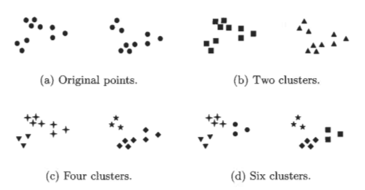

**Different Types of Clusterings**

1. *Exclusive* versus *Overlapping* versus *Fuzzy*
- *Exclusive* - assign each object to a single cluster
- Point could reasonably be placed in more than one cluster (non-exclusive clustering). Simultaneously belong to more than one group. (2)
- Every object belongs to every cluster with a membership weight that is between 0 (absolutely doesn’t belong) and 1 (absolutely belongs). - does not address true multiclass situations.

F1 = {(1, 0.9), (2,0.8), (3, 0.7), (4,0)} F2 = {(1,0), (2, 0.7), (3, 0.4), (4,0.9)}

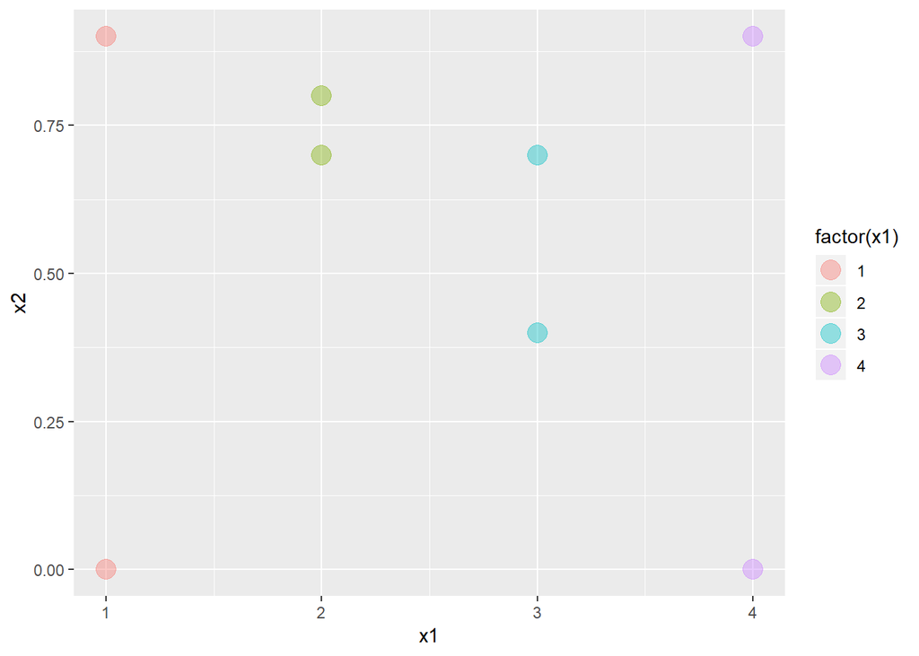

```r
x1 <- c(1,2,3,4,1,2,3,4)
x2 <- c(0.9, 0.8, 0.7, 0, 0, 0.7, 0.4, 0.9)
library(ggplot2)
ggplot(data.frame(x1,x2), aes(x1,x2, col = factor(x1)))+
  geom_point(size = 5, alpha = 0.4)
```

2. *Complete* versus *partial*
- A *complete* clustering assigns every object to a cluster
- The motivation for a partial clustering is that some objects in a data set may not belong to well-defined groups. (noise, outliers)

**Different Types of Clusters**

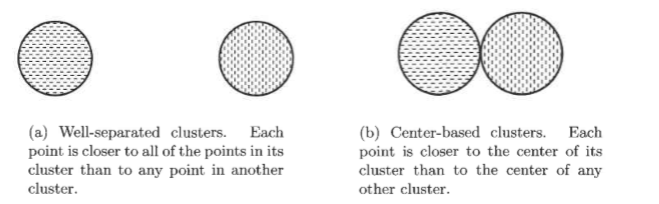

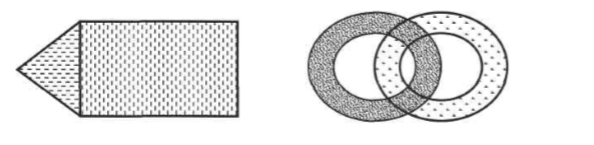

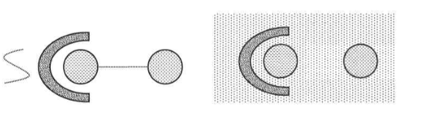

- While a **centroid** *almost never* corresponds to an **actual** data point, a **medoid**, by its definition, must be an **actual data** point.
- **Choosing initial K-s**

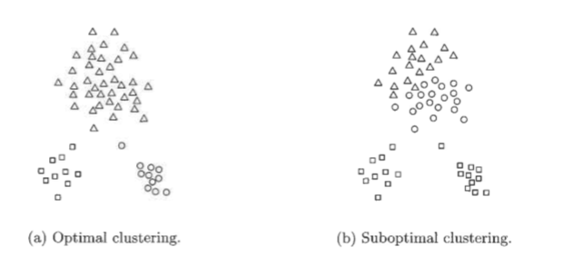

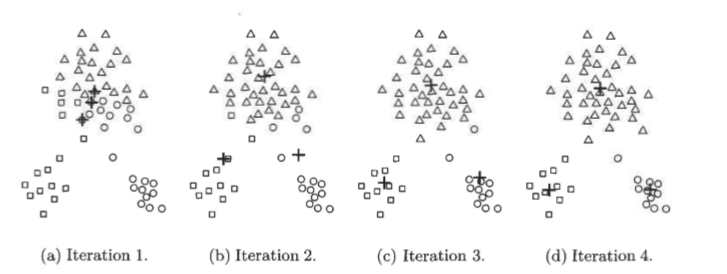

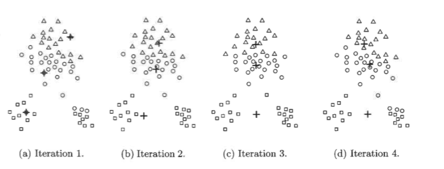

**How to choose k**

- One effective approach is to take a sample of points and cluster them using a **hierarchical clustering** technique.
- This approach often works well, but is practical only if (1) the sample is relatively small, a few hundred to a few thousand (hierarchical clustering is expensive), and (2) K is relatively small compared to the sample size.
- Select the point that is **farthest** from any of the initial centroids already selected (- outliers.)

**Bisecting K-means**

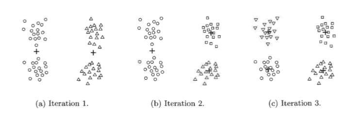

Bisecting K-means has less trouble with initialization because it performs several trial bisections and takes the one with the lowest SSE, and because there are only two centroids at each step

**K-means and Different Types of Clusters**

- **Diferent sizes**
- **Different densities**
- **non-spherical shapes**

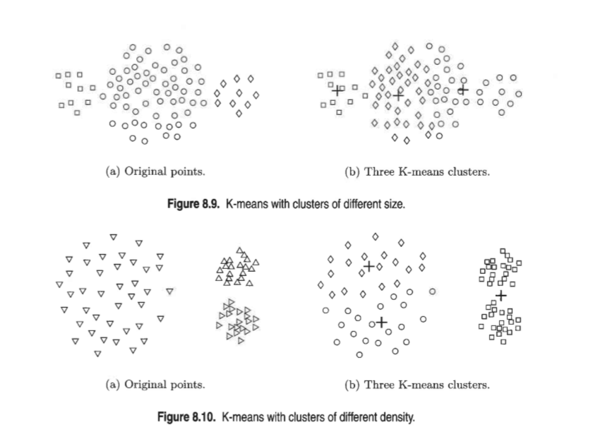

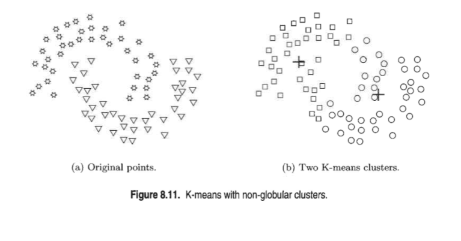

Limitations can be overcome

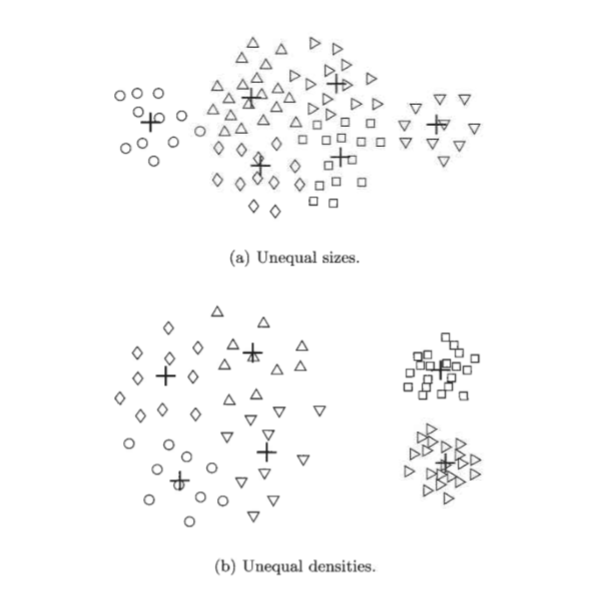

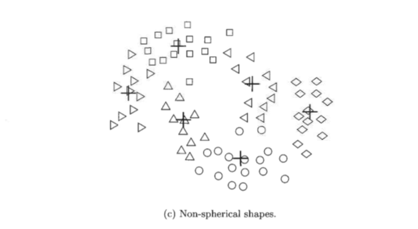

Each smaller cluster is pure in the sense that it contains only points from one of the natural clusters

**Goodness of clustering structure**

- **Unsupervised**
- **Supervised**
- **Relative** (both supervised and unsupervised)
- By adding new features
- Different means
- By using different algorithms

**Disadvantages**

- Sensitive to outliers
- Sensitive to initial points
- Categorical data
- Required k

One potential disadvantage of K-means clustering is that it requires us to pre-specify the number of clusters K.

**Hierarchical Clustering**

- One single dendrogram can be used to obtain any number of clusters
1. Agglomerative (cluster proximity)
2. Divisive (which cluster to split, how)

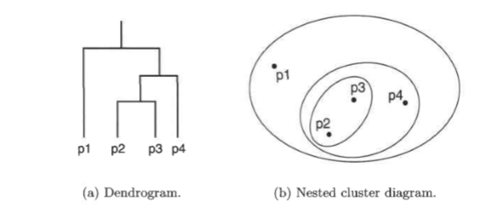